# CIND830S21_Assignment1_final

## CIND830 - Python Programming for Data Science

### Assignment 1 (10% of the final grade)

### Due on May 17, 2021 11:59 PM

This is a Jupyter Notebook document that extends a simple formatting syntax for authoring HTML and PDF. Review [this](https://jupyter-notebook.readthedocs.io/en/stable/notebook.html) website for more details on using Jupyter Notebooks.

Use the JupyterHub server on the Google Cloud Platform, provided by your designated instructor, for this assignment. Ensure using **Python 3.7.6** release then complete the assignment by inserting your Python code wherever seeing the string `#INSERT YOUR ANSWER HERE.`

When you click the `File` button, from the top navigation bar, then select `Export Notebook to HTML`, an HTML document will be generated that includes both the assignment content and the output of any embedded Python code chunks.

Use [these](https://www.ryerson.ca/courses/students/tutorials/assignments/) guidelines to submit **both** the IPYNB and the exported file (HTML). Failing to submit both files will be subject to mark deduction.

Please be advised that you cannot get more than 100% in this assignment, and the **BONUS** question will only be graded if all other questions have been submitted.

### Question 1 **[30 pts]**:

**a)** **[10 pts]** Write a Python program that accepts a list of marks then prints the letter grade and description according to the [Grading System](https://continuing.ryerson.ca/contentManagement.do?method=load&code=CM000034) of the Chang School of Continuing Education.

For example, if the user enters `90, 120, -12, 71.5, 62.5`, the output would be as follows:

| Mark | Letter Grade | Performance Description |
| --- | --- | --- |
| 90 | A+ | Excellent |
| 120 | Not Possible | Not Possible |
| -12 | Not Possible | Not Possible |
| 71.5 | B- | Good |
| 62.5 | C | Satisfactory |

```python
#INSERT YOUR ANSWER HERE.
#get the input from user
def marks():
  inp = input('Please enter the marks for the program with commas seperating them: ')
  marks = inp.split(",")

  #convert to integers
  marks_int = []
  for i in marks:
    marks_int.append(float(i))

  print('\nThe marks entered are: ', marks_int)
  return marks_int

#check if the marks are appropriate
'''
marks_int = [i for i in marks_int if i >= 0 and i < 100]
print('The Updated marks are: ', marks_int)
'''
marks_int = marks()
#Conditional statements for letter grading
print('-' * 50)
print('\n\nMarks\tLetter Grade\tPerfromace Description')
for j in (marks_int):
  if j >= 0 and j <= 100:
      if j <= 49 and j > -1:
       print('%.1f:\t%s\t\t%s' % (j, 'F', 'Unsatisfactory'))
      elif j <= 52:
        print('%.1f:\t%s\t\t%s' % (j, 'D-', 'Marginal'))
      elif j <= 56:
        print('%.1f:\t%s\t\t%s' % (j, 'D', 'Marginal'))
      elif j <= 59:
        print('%.1f:\t%s\t\t%s' % (j, 'D+', 'Marginal'))
      elif j <= 62:
        print('%.1f:\t%s\t\t%s' % (j, 'C-', 'Satisfactory'))
      elif j <= 66:
        print('%.1f:\t%s\t\t%s' % (j, 'C', 'Satisfactory'))
      elif j <= 69:
        print('%.1f:\t%s\t\t%s' % (j, 'C+', 'Satisfactory'))
      elif j <= 72:
        print('%.1f:\t%s\t\t%s' % (j, 'B-', 'Good'))
      elif j <= 76:
        print('%.1f:\t%s\t\t%s' % (j, 'B', 'Good'))
      elif j <= 79:
        print('%.1f:\t%s\t\t%s' % (j, 'B+', 'Good'))
      elif j <= 84:
        print('%.1f:\t%s\t\t%s' % (j, 'A-', 'Excellent'))
      elif j <= 89:
        print('%.1f:\t%s\t\t%s' % (j, 'A', 'Excellent'))
      elif j <= 100:
        print('%.1f:\t%s\t\t%s' % (j, 'A+', 'Excellent'))
  else:
    print('%.1f:\t%s\t\t%s' % (j, 'N/A', 'Not Possible'))

print('-' * 50)
```

```
Please enter the marks for the program with commas seperating them: 90, 120, -12, 71.5, 62.5

The marks entered are:  [90.0, 120.0, -12.0, 71.5, 62.5]
--------------------------------------------------


Marks	Letter Grade	Perfromace Description
90.0:	A+		Excellent
120.0:	N/A		Not Possible
-12.0:	N/A		Not Possible
71.5:	B-		Good
62.5:	C		Satisfactory
--------------------------------------------------
```

**b)** **[10 pts]** Write a code to compute and print the sum of squares of only the `Excellent` marks.

For example, if the user enters `90.5, 120, -12, 71.3, 82.2, 62.5`, then the output should be:  
`The Excellent marks are: [90.5, 82.2]`  
`The sum of squares is 14947.09`

```python
#INSERT YOUR ANSWER HERE.
#get the input from user
ex_marks = marks()

#check if the marks are appropriate

ex_marks = [i for i in ex_marks if i > 79 and i <= 100]
print('-' * 50)
print('The Excellent marks are: ', ex_marks)

#Find the sum of squares
sum = 0
for k in ex_marks:
  square = k ** 2
  sum += square

print('The sum of squares is: %.2f' %sum)
```

```
Please enter the marks for the program with commas seperating them: 90.5, 120, -12, 71.3, 82.2, 62.5

The marks entered are:  [90.5, 120.0, -12.0, 71.3, 82.2, 62.5]
--------------------------------------------------
The Excellent marks are:  [90.5, 82.2]
The sum of squares is: 14947.09
```

**c)** **[10 pts]** Write a code to compute and print the `Median`, `Average` and `Mode` of the marks between 0 and 100 after rounding each mark to the nearest integer. Ensure notifying the user if there is no unique mode found, as the `Mode` in this exercise returns only the single most common mark in the list.

For example, if the user enters `89.7, 120, -12, 90, 60.2`, then the output should be:  
`The valid marks are: [90, 90, 60]`  
`Median is 90 ; Average is 80 ; Mode is 90`

However, if the user enters `90.6, 70, 100, 40.4`, then the output should be:  
`The valid marks are: [91, 70, 100, 40]`  
`Median is 80.5 ; Average is 75.25 ; No unique mode found`

Also, if the user enters `65, 65, 65, 35, 35, 35`, then the output should be:  
`The valid marks are: [65, 65, 65, 35, 35, 35]`  
`Median is 50.0 ; Average is 50 ; No unique mode found`

**Hint:** Use the `statistics` module as it provides functions to calculate mathematical statistics of numeric data.

```python
#INSERT YOUR ANSWER HERE.
import statistics

#get the input from user
valid_marks = marks()

#Find the valid marks
valid_marks = [i for i in valid_marks if i >= 0 and i <= 100]

#round the marks to nearest integer
valid = []
for i in valid_marks:
  valid.append(round(i))
print('The Valid marks are: ', valid)

#Find median of the marks
try:
  print('The Median is %.2f; The Average is %.2f; The mode is %.2f' %(statistics.median(valid), statistics.mean(valid), statistics.mode(valid)))
except:
  print('The Median is %.2f; The Average is %.2f; No unique mode found' %(statistics.median(valid), statistics.mean(valid)))



#89.7,120,-12,90,60.2
#90.6, 70, 100, 40.4
#65,65,65,35,35,35
```

```
Please enter the marks for the program with commas seperating them: 89.7, 120, -12, 90, 60.2

The marks entered are:  [89.7, 120.0, -12.0, 90.0, 60.2]
The Valid marks are:  [90, 90, 60]
The Median is 90.00; The Average is 80.00; The mode is 90.00
```

### Question 2 **[40 pts]**:

**a)** **[10 pts]** Write a code that creates a set of different passwords. Each password is a combination of a random adjective, noun, two digits and two punctuation symbols.

For example, if the user asks for generating 4 passwords, then the code might generate the following list:

| Password |
| --- |
| supershine17*- |
| cheerfulmeet78~. |
| elitemango32&, |
| glossytrain14$} |

**Hint:** You can use the `wonderwords` library to generate random words of the English language

```python
#INSERT YOUR ANSWER HERE.
!pip install wonderwords

import string
import random
import wonderwords
from wonderwords import RandomWord
from random import randint

rand_word = RandomWord()

#ask the user for the number of passwords
def input_pw():
  input_num = input('Please enter the Number of passwords: ')
  input_num = int(input_num)
  print('-' * 50)
  return input_num



#function of a  loop to generate the pws for the number of times given by the user
def generate_pw(num):
  for i in range (num):
    first = rand_word.word(include_parts_of_speech=["adjectives"])
    second = rand_word.word(include_parts_of_speech=["nouns"])
    third = randint(10,99)
    last_1 = random.choice(string.punctuation)
    last_2 = random.choice(string.punctuation)
    all = first + second + str(third) + last_1 + last_2
    print(all)


num = input_pw()
generate_pw(num)
```

```
     |████████████████████████████████| 51kB 3.5MB/s
Please enter the Number of passwords: 4
--------------------------------------------------
holisticspade28*\
unevenstatin31@;
niftyarmpit22*\
legalpassenger10}'
```

**b)** **[10 pts]** Count the letters of each generated password in Q2.a, then print the password along with its number of letters.

For example, if the user enters 4, then the output might be as follows:

| Password | Length |
| --- | --- |
| supershine17*- | 14 |
| cheerfulmeet78~. | 16 |
| elitemango32&, | 14 |
| glossytrain14$} | 15 |

```python
#INSERT YOUR ANSWER HERE.
random.seed()

#function to generate pw and generate pw with length
def generate_pw_len(num):
  for i in range (num):
    first = rand_word.word(include_parts_of_speech=["adjectives"])
    second = rand_word.word(include_parts_of_speech=["nouns"])
    third = randint(10,99)
    last_1 = random.choice(string.punctuation)
    last_2 = random.choice(string.punctuation)
    all = first + second + str(third) + last_1 + last_2
    length = len(all)
    if (length <= 15):
      print(all + '\t\t ' + str(length))
    elif length >= 25:
      print(all + ' ' + str(length))
    else:
      print(all + '\t ' + str(length))


#call previous functions from question 2.a
num = input_pw()

print('Password\t\t Length')
print('-' * 50)

generate_pw_len(num)
```

```
Please enter the Number of passwords: 4
--------------------------------------------------
Password		 Length
--------------------------------------------------
tightambassador65[?	 19
ultraincident80*>	 17
huskychemical61\?	 17
bizarrebend25-!		 15
```

**c)** **[10 pts]** Write a code to print only the passwords with more than 14 letters and either the letter 'o', the digit '3', or the punctuation symbol '~'.

For example, the code would filter the 4 passwords listed in 2.a, and print the following output:

| Password | Length |
| --- | --- |
| cheerfulmeet78~. | 16 |
| glossytrain14$} | 15 |

```python
#INSERT YOUR ANSWER HERE.
#call function to find number of pws
num = input_pw()
print('The accepted Passwords are: ')
print('Password\t\t Length')

#generate passwords and their length
for i in range (num):
  first = rand_word.word(include_parts_of_speech=["adjectives"])
  second = rand_word.word(include_parts_of_speech=["nouns"])
  third = randint(10,99)
  last_1 = random.choice(string.punctuation)
  last_2 = random.choice(string.punctuation)
  all = first + second + str(third) + last_1 + last_2
  length = len(all)
  if length > 14:
    if (third == 'o') or (last_1 == '~') or (last_2 == '~'):
      print(all + '\t ' + str(length))
      if length > 19:
        print(all + ' ' + str(length))
```

```
Please enter the Number of passwords: 40
--------------------------------------------------
The accepted Passwords are:
Password		 Length
elfinjustification58=~	 22
elfinjustification58=~ 22
breakableartery41~'	 19
skillfulchard28~.	 17
```

**d)** **[10 pts]** Design an encoder that encrypts the passwords generated in Q2.a. by changing their letters into the octal form.

For example, if the user enters 4, then the output might be as follows

| Password | Encryption |
| --- | --- |
| supershine17*- | 0o1630o1650o1600o1450o1620o1630o1500o1510o1560o1450o610o670o520o55 |
| cheerfulmeet78~. | 0o1430o1500o1450o1450o1620o1460o1650o1540o1550o1450o1450o1640o670o700o1760o56 |
| elitemango32&, | 0o1450o1540o1510o1640o1450o1550o1410o1560o1470o1570o630o620o460o54 |
| glossytrain14$} | 0o1470o1540o1570o1630o1630o1710o1640o1620o1410o1510o1560o610o640o440o175 |

```python
#INSERT YOUR ANSWER HERE.
#call function to find number of pws
import string

num = input_pw()

print('Password\t\t\t Encryption ')
print('-' * 50)
for i in range (num):
  first = rand_word.word(include_parts_of_speech=["adjectives"])
  second = rand_word.word(include_parts_of_speech=["nouns"])
  third = randint(10,99)
  last_1 = random.choice(string.punctuation)
  last_2 = random.choice(string.punctuation)
  all = first + second + str(third) + last_1 + last_2

  octal = []
  l = []

#Use for loop to store encryption and print output
  for j in all:
    octal.append(oct(ord(j)))
    l = ''.join(octal)
  print(all + '\t\t' + l)
```

```
Please enter the Number of passwords: 3
--------------------------------------------------
Password			 Encryption
--------------------------------------------------
festivemonasticism87@[		0o1460o1450o1630o1640o1510o1660o1450o1550o1570o1560o1410o1630o1640o1510o1430o1510o1630o1550o700o670o1000o133
omniscientpolitician45~(		0o1570o1550o1560o1510o1630o1430o1510o1450o1560o1640o1600o1570o1540o1510o1640o1510o1430o1510o1410o1560o640o650o1760o50
iratepublic12!*		0o1510o1620o1410o1640o1450o1600o1650o1420o1540o1510o1430o610o620o410o52
```

### Question 3 **[30 pts]**:

Write a program that accepts the coefficients of the following two lines as inputs

Line1: $a_1x+b_1y + c_1 = 0$

Line2: $a_2x+b_2y + c_2 = 0$

Then checks whether the two lines are parallel, intersecting or overlapping according to the conditions listed below.

**a)** **[10 pts]** Intersecting lines: If $\frac{a_1}{a_2} \ne \frac{b_1}{b_2}$

```python
#INSERT YOUR ANSWER HERE.

import math

#function to ask user for values
def user_input():
  #Make arbitary varibales to store the values
  eqn1 = []
  eqn2 = []

  #Ask the user to enter the coeffs for the eqns
  header = ['Please enter the coeffs for the first equation - a1x + b1y + c1 = 0', 'Please enter the coeffs for the second equation - a1x + b1y + c1 = 0']
  print(header[0])
  for i in range(0,3):
    num1 = int(input('Coefficent ' + str(i + 1) + ' - '))
    eqn1.append(num1)

  print(header[1])
  for j in range(0,3):
    num2 = int(input('Coefficent ' + str(j + 1) + ' - '))
    eqn2.append(num2)

  return eqn1, eqn2

var1, var2 = user_input()

#find whether or not the equation is intersecting
num_1 = var1[0] / var2[0]
num_2 = var1[1] / var2[1]
num_3 = var1[2] / var2[2]

print('-' * 50)
if num_1 == num_2:
  print('The lines for these equations will not intersect')
else:
  print('The lines for these equations will intersect')
```

```
Please enter the coeffs for the first equation - a1x + b1y + c1 = 0
Coefficent 1 - 2
Coefficent 2 - 3
Coefficent 3 - 4
Please enter the coeffs for the second equation - a1x + b1y + c1 = 0
Coefficent 1 - 2
Coefficent 2 - 4
Coefficent 3 - 3
--------------------------------------------------
The lines for these equations will intersect
```

**b)** **[10 pts]** Parallel lines: If the lines are not intersecting and $\frac{a_1}{a_2} = \frac{b_1}{b_2} \ne \frac{c_1}{c_2}$

```python
#INSERT YOUR ANSWER HERE.
#Call user_input function from previous code
var1, var2 = user_input()

#decalre varibales for each math operation which are num_1, num_2 and num_3
num_1 = var1[0] / var2[0]
num_2 = var1[1] / var2[1]
num_3 = var1[2] / var2[2]

#determine whether or not the lines intersect are parallel or neither in some cases
if num_1 == num_2:
  if num_2 != num_3:
    print('These are parallel lines as the lines are not intersecting')
  else:
    print('These are not parallel lines and the lines are not intersecting')
else:
  print('These are not parallel lines but the lines are intersecting')
```

```
Please enter the coeffs for the first equation - a1x + b1y + c1 = 0
Coefficent 1 - 2
Coefficent 2 - 3
Coefficent 3 - 4
Please enter the coeffs for the second equation - a1x + b1y + c1 = 0
Coefficent 1 - 2
Coefficent 2 - 3
Coefficent 3 - 3
These are parallel lines as the lines are not intersecting
```

**c)** **[10 pts]** Overlapping lines: If the lines are not intersecting and $\frac{a_1}{a_2} = \frac{b_1}{b_2} = \frac{c_1}{c_2}$

```python
#INSERT YOUR ANSWER HERE.
#Call user_input function from previous code
var1, var2 = user_input()

#decalre varibales for each math operation which are num_1, num_2 and num_3
num_1 = var1[0] / var2[0]
num_2 = var1[1] / var2[1]
num_3 = var1[2] / var2[2]

#determine whether or not the lines intersect are parallel or neither in some cases
if num_1 == num_2:
  if num_2 == num_3:
    print('These are Overlapping lines and not parallel lines as the lines are not intersecting')
  else:
    print('These are neither overlapping lines nor intersecting lines but are parallel lines')
else:
  print('These are neither parallel nor overlapping lines but the lines are intersecting')
```

```
Please enter the coeffs for the first equation - a1x + b1y + c1 = 0
Coefficent 1 - 2
Coefficent 2 - 3
Coefficent 3 - 4
Please enter the coeffs for the second equation - a1x + b1y + c1 = 0
Coefficent 1 - 2
Coefficent 2 - 3
Coefficent 3 - 4
These are Overlapping lines and not parallel lines as the lines are not intersecting
```

**BONUS** **[10 pts]** Plot the two lines graphically using the `matplotlib` and `numpy` libraries or any other suitable libraries.

```
Please enter the coeffs for the first equation - a1x + b1y + c1 = 0
Coefficent 1 - 2
Coefficent 2 - 3
Coefficent 3 - 4
Please enter the coeffs for the second equation - a1x + b1y + c1 = 0
Coefficent 1 - 2
Coefficent 2 - 3
Coefficent 3 - 4
--------------------------------------------------
Plot number 1
```

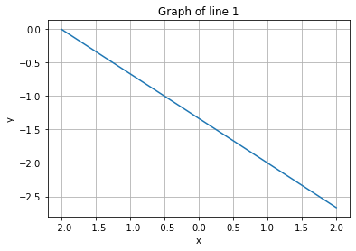

```
--------------------------------------------------

Plot number 2
```

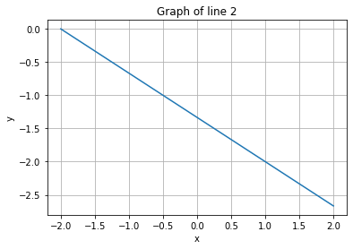

```python
#INSERT YOUR ANSWER HERE.
import matplotlib.pyplot as plt
import numpy as np

#Call user_input function from previous code
var1, var2 = user_input()

def plot_line(coeff1, num):
  #plot for first line
  y1 = coeff1[1]
  x1 = coeff1[0]
  b1 = coeff1[2]

  x = np.linspace(-x1, x1, 100)
  y = (-x1*x - b1) / y1
  plt.plot(x, y)
  plt.xlabel('x')
  plt.ylabel('y')
  plt.title('Graph of line ' + num)
  plt.grid()
  plt.show()

print('-' * 50)
print('Plot number 1')
plot_line(var1, str(1))

print('-' * 50)
print('\nPlot number 2')
plot_line(var2, str(2))
```

#### This is the end of assignment 1